← back

# Team Project: Airbnb Business Analysis

Our team project was to take an Airbnb dataset for New York in 2019, and apply machine learning approaches to analyse business trends.

Our team chose this business question.

*Is a proposed price for a given room type in a given neighbourhood underpriced, in price range, or overpriced?*

Abdullah began by loading and inspecting the Airbnb data.

```python
import pandas as pd
import numpy as np
import matplotlib.pyplot as plt
import seaborn as sns
```

```python
df = pd.read_csv('AB_NYC_2019.csv')
```

```python
df.head()
```

|  | id | name | host_id | host_name | neighbourhood_group | neighbourhood | latitude | longitude | room_type | price | minimum_nights | number_of_reviews | last_review | reviews_per_month | calculated_host_listings_count | availability_365 |
| --- | --- | --- | --- | --- | --- | --- | --- | --- | --- | --- | --- | --- | --- | --- | --- | --- |
| 0 | 2539 | Clean & quiet apt home by the park | 2787 | John | Brooklyn | Kensington | 40.64749 | -73.97237 | Private room | 149 | 1 | 9 | 2018-10-19 | 0.21 | 6 | 365 |
| 1 | 2595 | Skylit Midtown Castle | 2845 | Jennifer | Manhattan | Midtown | 40.75362 | -73.98377 | Entire home/apt | 225 | 1 | 45 | 2019-05-21 | 0.38 | 2 | 355 |
| 2 | 3647 | THE VILLAGE OF HARLEM....NEW YORK ! | 4632 | Elisabeth | Manhattan | Harlem | 40.80902 | -73.94190 | Private room | 150 | 3 | 0 | NaN | NaN | 1 | 365 |
| 3 | 3831 | Cozy Entire Floor of Brownstone | 4869 | LisaRoxanne | Brooklyn | Clinton Hill | 40.68514 | -73.95976 | Entire home/apt | 89 | 1 | 270 | 2019-07-05 | 4.64 | 1 | 194 |
| 4 | 5022 | Entire Apt: Spacious Studio/Loft by central park | 7192 | Laura | Manhattan | East Harlem | 40.79851 | -73.94399 | Entire home/apt | 80 | 10 | 9 | 2018-11-19 | 0.10 | 1 | 0 |

```python
df.columns
```

```
Index(['id', 'name', 'host_id', 'host_name', 'neighbourhood_group',
       'neighbourhood', 'latitude', 'longitude', 'room_type', 'price',
       'minimum_nights', 'number_of_reviews', 'last_review',
       'reviews_per_month', 'calculated_host_listings_count',
       'availability_365'],
      dtype='object')
```

```python
df.info()
```

```
<class 'pandas.core.frame.DataFrame'>
RangeIndex: 48895 entries, 0 to 48894
Data columns (total 16 columns):
 #   Column                          Non-Null Count  Dtype
---  ------                          --------------  -----
 0   id                              48895 non-null  int64
 1   name                            48879 non-null  object
 2   host_id                         48895 non-null  int64
 3   host_name                       48874 non-null  object
 4   neighbourhood_group             48895 non-null  object
 5   neighbourhood                   48895 non-null  object
 6   latitude                        48895 non-null  float64
 7   longitude                       48895 non-null  float64
 8   room_type                       48895 non-null  object
 9   price                           48895 non-null  int64
 10  minimum_nights                  48895 non-null  int64
 11  number_of_reviews               48895 non-null  int64
 12  last_review                     38843 non-null  object
 13  reviews_per_month               38843 non-null  float64
 14  calculated_host_listings_count  48895 non-null  int64
 15  availability_365                48895 non-null  int64
dtypes: float64(3), int64(7), object(6)
memory usage: 6.0+ MB
```

```python
df.describe()
```

|  | id | host_id | latitude | longitude | price | minimum_nights | number_of_reviews | reviews_per_month | calculated_host_listings_count | availability_365 |
| --- | --- | --- | --- | --- | --- | --- | --- | --- | --- | --- |
| count | 4.889500e+04 | 4.889500e+04 | 48895.000000 | 48895.000000 | 48895.000000 | 48895.000000 | 48895.000000 | 38843.000000 | 48895.000000 | 48895.000000 |
| mean | 1.901714e+07 | 6.762001e+07 | 40.728949 | -73.952170 | 152.720687 | 7.029962 | 23.274466 | 1.373221 | 7.143982 | 112.781327 |
| std | 1.098311e+07 | 7.861097e+07 | 0.054530 | 0.046157 | 240.154170 | 20.510550 | 44.550582 | 1.680442 | 32.952519 | 131.622289 |
| min | 2.539000e+03 | 2.438000e+03 | 40.499790 | -74.244420 | 0.000000 | 1.000000 | 0.000000 | 0.010000 | 1.000000 | 0.000000 |
| 25% | 9.471945e+06 | 7.822033e+06 | 40.690100 | -73.983070 | 69.000000 | 1.000000 | 1.000000 | 0.190000 | 1.000000 | 0.000000 |
| 50% | 1.967728e+07 | 3.079382e+07 | 40.723070 | -73.955680 | 106.000000 | 3.000000 | 5.000000 | 0.720000 | 1.000000 | 45.000000 |
| 75% | 2.915218e+07 | 1.074344e+08 | 40.763115 | -73.936275 | 175.000000 | 5.000000 | 24.000000 | 2.020000 | 2.000000 | 227.000000 |
| max | 3.648724e+07 | 2.743213e+08 | 40.913060 | -73.712990 | 10000.000000 | 1250.000000 | 629.000000 | 58.500000 | 327.000000 | 365.000000 |

```python
df.shape
```

```
(48895, 16)
```

### Data Types

```python
print("Data Types:\n")
print(df.dtypes)
```

```
Data Types:

id                                  int64
name                               object
host_id                             int64
host_name                          object
neighbourhood_group                object
neighbourhood                      object
latitude                          float64
longitude                         float64
room_type                          object
price                               int64
minimum_nights                      int64
number_of_reviews                   int64
last_review                        object
reviews_per_month                 float64
calculated_host_listings_count      int64
availability_365                    int64
dtype: object
```

### Price Variable

```python
print("Price Statistics:\n")
print(df['price'].describe())
```

```
Price Statistics:

count    48895.000000
mean       152.720687
std        240.154170
min          0.000000
25%         69.000000
50%        106.000000
75%        175.000000
max      10000.000000
Name: price, dtype: float64
```

### Neighborhood Variable

```python
print(df['neighbourhood_group'].value_counts())
```

```
neighbourhood_group
Manhattan        21661
Brooklyn         20104
Queens            5666
Bronx             1091
Staten Island      373
Name: count, dtype: int64
```

### Room Type Variable

```python
print(df['room_type'].value_counts())
```

```
room_type
Entire home/apt    25409
Private room       22326
Shared room         1160
Name: count, dtype: int64
```

### Availability Variable

```python
print(df['availability_365'].describe())
```

```
count    48895.000000
mean       112.781327
std        131.622289
min          0.000000
25%          0.000000
50%         45.000000
75%        227.000000
max        365.000000
Name: availability_365, dtype: float64
```

### Missing Values

```python
missing_values = df.isnull().sum()

print("Missing Values Per Column:\n")
print(missing_values)
```

```
Missing Values Per Column:

id                                    0
name                                 16
host_id                               0
host_name                            21
neighbourhood_group                   0
neighbourhood                         0
latitude                              0
longitude                             0
room_type                             0
price                                 0
minimum_nights                        0
number_of_reviews                     0
last_review                       10052
reviews_per_month                 10052
calculated_host_listings_count        0
availability_365                      0
dtype: int64
```

### Duplicate Values Check

```python
duplicates = df.duplicated().sum()

print("Total Duplicate Rows:", duplicates)
```

```
Total Duplicate Rows: 0
```

### Unique Values in Categorical Variables

```python
categorical_columns = df.select_dtypes(include=['object']).columns

for col in categorical_columns:
    print(f"\nColumn: {col}")
    print(df[col].nunique())
```

```
Column: name
47905

Column: host_name
11452

Column: neighbourhood_group
5

Column: neighbourhood
221

Column: room_type
3

Column: last_review
1764
```

### Understanding Dataset

```python
numerical_columns = df.select_dtypes(include=['int64', 'float64']).columns
categorical_columns = df.select_dtypes(include=['object']).columns

print("Numerical Columns:\n")
print(numerical_columns)

print("\nCategorical Columns:\n")
print(categorical_columns)
```

```
Numerical Columns:

Index(['id', 'host_id', 'latitude', 'longitude', 'price', 'minimum_nights',
       'number_of_reviews', 'reviews_per_month',
       'calculated_host_listings_count', 'availability_365'],
      dtype='object')

Categorical Columns:

Index(['name', 'host_name', 'neighbourhood_group', 'neighbourhood',
       'room_type', 'last_review'],
      dtype='object')
```

Correlation Analysis

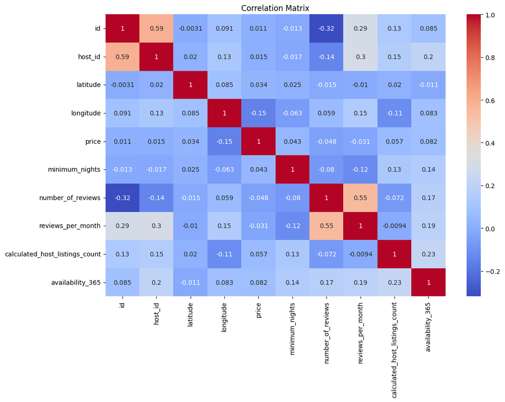

```python
correlation_matrix = df.corr(numeric_only=True)

plt.figure(figsize=(12,8))
sns.heatmap(correlation_matrix, annot=True, cmap='coolwarm')
plt.title('Correlation Matrix')
plt.show()
```

Leah and I then pre-processed the Airbnb data.

# Airbnb Dataset Cleaning & Preprocessing

## Objective

This notebook cleans and preprocesses the Airbnb NYC 2019 dataset for further analysis and machine learning tasks.

## 1. Import Libraries

```python
import pandas as pd
import numpy as np
import matplotlib.pyplot as plt
import seaborn as sns

sns.set_style('whitegrid')
```

## 2. Load Dataset

```python
df = pd.read_csv('AB_NYC_2019.csv')

df.head()
```

|  | id | name | host_id | host_name | neighbourhood_group | neighbourhood | latitude | longitude | room_type | price | minimum_nights | number_of_reviews | last_review | reviews_per_month | calculated_host_listings_count | availability_365 |
| --- | --- | --- | --- | --- | --- | --- | --- | --- | --- | --- | --- | --- | --- | --- | --- | --- |
| 0 | 2539 | Clean & quiet apt home by the park | 2787 | John | Brooklyn | Kensington | 40.64749 | -73.97237 | Private room | 149 | 1 | 9 | 2018-10-19 | 0.21 | 6 | 365 |
| 1 | 2595 | Skylit Midtown Castle | 2845 | Jennifer | Manhattan | Midtown | 40.75362 | -73.98377 | Entire home/apt | 225 | 1 | 45 | 2019-05-21 | 0.38 | 2 | 355 |
| 2 | 3647 | THE VILLAGE OF HARLEM....NEW YORK ! | 4632 | Elisabeth | Manhattan | Harlem | 40.80902 | -73.94190 | Private room | 150 | 3 | 0 | NaN | NaN | 1 | 365 |
| 3 | 3831 | Cozy Entire Floor of Brownstone | 4869 | LisaRoxanne | Brooklyn | Clinton Hill | 40.68514 | -73.95976 | Entire home/apt | 89 | 1 | 270 | 2019-07-05 | 4.64 | 1 | 194 |
| 4 | 5022 | Entire Apt: Spacious Studio/Loft by central park | 7192 | Laura | Manhattan | East Harlem | 40.79851 | -73.94399 | Entire home/apt | 80 | 10 | 9 | 2018-11-19 | 0.10 | 1 | 0 |

## 3. Dataset Overview

```python
df.info()
```

```
<class 'pandas.DataFrame'>
RangeIndex: 48895 entries, 0 to 48894
Data columns (total 16 columns):
 #   Column                          Non-Null Count  Dtype
---  ------                          --------------  -----
 0   id                              48895 non-null  int64
 1   name                            48879 non-null  str
 2   host_id                         48895 non-null  int64
 3   host_name                       48874 non-null  str
 4   neighbourhood_group             48895 non-null  str
 5   neighbourhood                   48895 non-null  str
 6   latitude                        48895 non-null  float64
 7   longitude                       48895 non-null  float64
 8   room_type                       48895 non-null  str
 9   price                           48895 non-null  int64
 10  minimum_nights                  48895 non-null  int64
 11  number_of_reviews               48895 non-null  int64
 12  last_review                     38843 non-null  str
 13  reviews_per_month               38843 non-null  float64
 14  calculated_host_listings_count  48895 non-null  int64
 15  availability_365                48895 non-null  int64
dtypes: float64(3), int64(7), str(6)
memory usage: 6.0 MB
```

```python
df.describe(include='all')
```

|  | id | name | host_id | host_name | neighbourhood_group | neighbourhood | latitude | longitude | room_type | price | minimum_nights | number_of_reviews | last_review | reviews_per_month | calculated_host_listings_count | availability_365 |
| --- | --- | --- | --- | --- | --- | --- | --- | --- | --- | --- | --- | --- | --- | --- | --- | --- |
| count | 4.889500e+04 | 48879 | 4.889500e+04 | 48874 | 48895 | 48895 | 48895.000000 | 48895.000000 | 48895 | 48895.000000 | 48895.000000 | 48895.000000 | 38843 | 38843.000000 | 48895.000000 | 48895.000000 |
| unique | NaN | 47905 | NaN | 11452 | 5 | 221 | NaN | NaN | 3 | NaN | NaN | NaN | 1764 | NaN | NaN | NaN |
| top | NaN | Hillside Hotel | NaN | Michael | Manhattan | Williamsburg | NaN | NaN | Entire home/apt | NaN | NaN | NaN | 2019-06-23 | NaN | NaN | NaN |
| freq | NaN | 18 | NaN | 417 | 21661 | 3920 | NaN | NaN | 25409 | NaN | NaN | NaN | 1413 | NaN | NaN | NaN |
| mean | 1.901714e+07 | NaN | 6.762001e+07 | NaN | NaN | NaN | 40.728949 | -73.952170 | NaN | 152.720687 | 7.029962 | 23.274466 | NaN | 1.373221 | 7.143982 | 112.781327 |
| std | 1.098311e+07 | NaN | 7.861097e+07 | NaN | NaN | NaN | 0.054530 | 0.046157 | NaN | 240.154170 | 20.510550 | 44.550582 | NaN | 1.680442 | 32.952519 | 131.622289 |
| min | 2.539000e+03 | NaN | 2.438000e+03 | NaN | NaN | NaN | 40.499790 | -74.244420 | NaN | 0.000000 | 1.000000 | 0.000000 | NaN | 0.010000 | 1.000000 | 0.000000 |
| 25% | 9.471945e+06 | NaN | 7.822033e+06 | NaN | NaN | NaN | 40.690100 | -73.983070 | NaN | 69.000000 | 1.000000 | 1.000000 | NaN | 0.190000 | 1.000000 | 0.000000 |
| 50% | 1.967728e+07 | NaN | 3.079382e+07 | NaN | NaN | NaN | 40.723070 | -73.955680 | NaN | 106.000000 | 3.000000 | 5.000000 | NaN | 0.720000 | 1.000000 | 45.000000 |
| 75% | 2.915218e+07 | NaN | 1.074344e+08 | NaN | NaN | NaN | 40.763115 | -73.936275 | NaN | 175.000000 | 5.000000 | 24.000000 | NaN | 2.020000 | 2.000000 | 227.000000 |
| max | 3.648724e+07 | NaN | 2.743213e+08 | NaN | NaN | NaN | 40.913060 | -73.712990 | NaN | 10000.000000 | 1250.000000 | 629.000000 | NaN | 58.500000 | 327.000000 | 365.000000 |

## 4. Convert Columns to Correct Data Types

```python
df['last_review'] = pd.to_datetime(df['last_review'])

categorical_columns = [
    'neighbourhood_group',
    'neighbourhood',
    'room_type'
]

for col in categorical_columns:
    df[col] = df[col].astype('category')

df.dtypes
```

```
id                                         int64
name                                         str
host_id                                    int64
host_name                                    str
neighbourhood_group                     category
neighbourhood                           category
latitude                                 float64
longitude                                float64
room_type                               category
price                                      int64
minimum_nights                             int64
number_of_reviews                          int64
last_review                       datetime64[us]
reviews_per_month                        float64
calculated_host_listings_count             int64
availability_365                           int64
dtype: object
```

## 5. Check Missing Values

```python
df.isnull().sum()
```

```
id                                    0
name                                 16
host_id                               0
host_name                            21
neighbourhood_group                   0
neighbourhood                         0
latitude                              0
longitude                             0
room_type                             0
price                                 0
minimum_nights                        0
number_of_reviews                     0
last_review                       10052
reviews_per_month                 10052
calculated_host_listings_count        0
availability_365                      0
dtype: int64
```

### Observations

- `name` and `host_name` contain a few missing values.
- `last_review` and `reviews_per_month` contain many missing values because some listings have never been reviewed.

## 6. Remove Duplicates

```python
print("Rows before duplicate removal:", len(df))

df = df.drop_duplicates()

print("Rows after duplicate removal:", len(df))
```

```
Rows before duplicate removal: 48895
Rows after duplicate removal: 48895
```

## 7. Handle Missing Values

```python
df['reviews_per_month'] = df['reviews_per_month'].fillna(0)

df['name'] = df['name'].fillna('Unknown')

df['host_name'] = df['host_name'].fillna('Unknown')
```

## 8. Remove Invalid Prices

```python
print("Rows before removing invalid prices:", len(df))

df = df[df['price'] > 0]

print("Rows after removing invalid prices:", len(df))
```

```
Rows before removing invalid prices: 48895
Rows after removing invalid prices: 48884
```

## 9. Remove Extreme Price Outliers

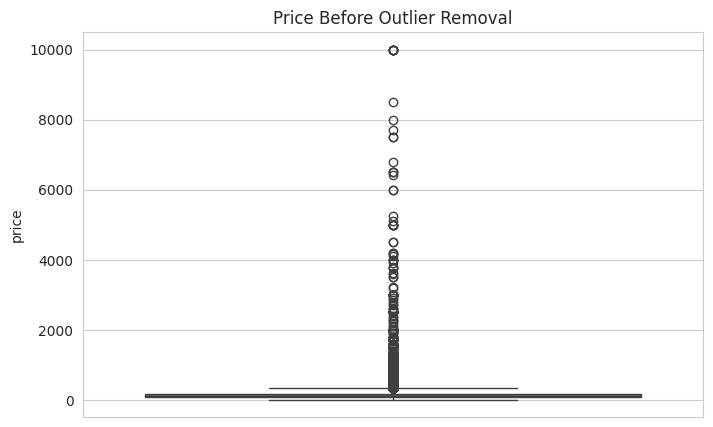

```python
plt.figure(figsize=(8,5))
sns.boxplot(y=df['price'])
plt.title('Price Before Outlier Removal')
plt.show()
```

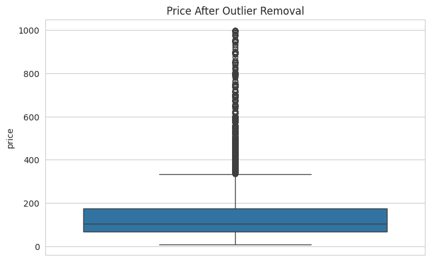

```python
df = df[df['price'] < 1000]

plt.figure(figsize=(8,5))
sns.boxplot(y=df['price'])
plt.title('Price After Outlier Removal')
plt.show()
```

## 10. Remove Extreme Minimum Nights Outliers

```python
df = df[df['minimum_nights'] <= 365]
```

## 11. Feature Engineering

```python
df['month'] = df['last_review'].dt.month

def get_season(month):
    if month in [12, 1, 2]:
        return 'Winter'
    elif month in [3, 4, 5]:
        return 'Spring'
    elif month in [6, 7, 8]:
        return 'Summer'
    else:
        return 'Autumn'

df['season'] = df['month'].apply(get_season)

df[['last_review', 'month', 'season']].head()
```

|  | last_review | month | season |
| --- | --- | --- | --- |
| 0 | 2018-10-19 | 10.0 | Autumn |
| 1 | 2019-05-21 | 5.0 | Spring |
| 2 | NaT | NaN | Autumn |
| 3 | 2019-07-05 | 7.0 | Summer |
| 4 | 2018-11-19 | 11.0 | Autumn |

## 12. Final Dataset Summary

```python
df.info()
```

```
<class 'pandas.DataFrame'>
Index: 48572 entries, 0 to 48894
Data columns (total 18 columns):
 #   Column                          Non-Null Count  Dtype
---  ------                          --------------  -----
 0   id                              48572 non-null  int64
 1   name                            48572 non-null  str
 2   host_id                         48572 non-null  int64
 3   host_name                       48572 non-null  str
 4   neighbourhood_group             48572 non-null  category
 5   neighbourhood                   48572 non-null  category
 6   latitude                        48572 non-null  float64
 7   longitude                       48572 non-null  float64
 8   room_type                       48572 non-null  category
 9   price                           48572 non-null  int64
 10  minimum_nights                  48572 non-null  int64
 11  number_of_reviews               48572 non-null  int64
 12  last_review                     38690 non-null  datetime64[us]
 13  reviews_per_month               48572 non-null  float64
 14  calculated_host_listings_count  48572 non-null  int64
 15  availability_365                48572 non-null  int64
 16  month                           38690 non-null  float64
 17  season                          48572 non-null  str
dtypes: category(3), datetime64[us](1), float64(4), int64(7), str(3)
memory usage: 6.1 MB
```

```python
df.describe(include='all')
```

|  | id | name | host_id | host_name | neighbourhood_group | neighbourhood | latitude | longitude | room_type | price | minimum_nights | number_of_reviews | last_review | reviews_per_month | calculated_host_listings_count | availability_365 | month | season |
| --- | --- | --- | --- | --- | --- | --- | --- | --- | --- | --- | --- | --- | --- | --- | --- | --- | --- | --- |
| count | 4.857200e+04 | 48572 | 4.857200e+04 | 48572 | 48572 | 48572 | 48572.000000 | 48572.000000 | 48572 | 48572.000000 | 48572.000000 | 48572.000000 | 38690 | 48572.000000 | 48572.000000 | 48572.000000 | 38690.000000 | 48572 |
| unique | NaN | 47591 | NaN | 11403 | 5 | 221 | NaN | NaN | 3 | NaN | NaN | NaN | NaN | NaN | NaN | NaN | NaN | 4 |
| top | NaN | Hillside Hotel | NaN | Michael | Manhattan | Williamsburg | NaN | NaN | Entire home/apt | NaN | NaN | NaN | NaN | NaN | NaN | NaN | NaN | Summer |
| freq | NaN | 18 | NaN | 415 | 21441 | 3905 | NaN | NaN | 25155 | NaN | NaN | NaN | NaN | NaN | NaN | NaN | NaN | 21136 |
| mean | 1.902306e+07 | NaN | 6.764521e+07 | NaN | NaN | NaN | 40.728927 | -73.952028 | NaN | 140.269826 | 6.784176 | 23.378016 | 2018-10-04 15:19:20.672008 | 1.095586 | 7.170345 | 112.314440 | 6.174464 | NaN |
| min | 2.539000e+03 | NaN | 2.438000e+03 | NaN | NaN | NaN | 40.499790 | -74.244420 | NaN | 10.000000 | 1.000000 | 0.000000 | 2011-03-28 00:00:00 | 0.000000 | 1.000000 | 0.000000 | 1.000000 | NaN |
| 25% | 9.476845e+06 | NaN | 7.831209e+06 | NaN | NaN | NaN | 40.690000 | -73.982950 | NaN | 69.000000 | 1.000000 | 1.000000 | 2018-07-10 00:00:00 | 0.040000 | 1.000000 | 0.000000 | 5.000000 | NaN |
| 50% | 1.967743e+07 | NaN | 3.085513e+07 | NaN | NaN | NaN | 40.722960 | -73.955580 | NaN | 105.000000 | 3.000000 | 5.000000 | 2019-05-19 00:00:00 | 0.380000 | 1.000000 | 44.000000 | 6.000000 | NaN |
| 75% | 2.914961e+07 | NaN | 1.074344e+08 | NaN | NaN | NaN | 40.763130 | -73.936100 | NaN | 175.000000 | 5.000000 | 24.000000 | 2019-06-23 00:00:00 | 1.600000 | 2.000000 | 225.000000 | 7.000000 | NaN |
| max | 3.648724e+07 | NaN | 2.743213e+08 | NaN | NaN | NaN | 40.913060 | -73.712990 | NaN | 999.000000 | 365.000000 | 629.000000 | 2019-07-08 00:00:00 | 58.500000 | 327.000000 | 365.000000 | 12.000000 | NaN |
| std | 1.097852e+07 | NaN | 7.861058e+07 | NaN | NaN | NaN | 0.054582 | 0.046160 | NaN | 112.904535 | 16.129464 | 44.656757 | NaN | 1.600025 | 33.050706 | 131.352383 | 2.529264 | NaN |

## 13. Save Cleaned Dataset

```python
df.to_csv('airbnb_cleaned.csv', index=False)

print("Cleaned dataset saved as airbnb_cleaned.csv")
```

```
Cleaned dataset saved as airbnb_cleaned.csv
```

# Conclusion

The dataset has been cleaned and prepared for:

- Exploratory Data Analysis (EDA)
- Machine learning
- Anomaly detection
- Neural Architecture Search (NAS)

The cleaned dataset was saved as `airbnb_cleaned.csv`.

Leah did some exploratory data analysis.

# Airbnb Pricing Analysis - Exploratory Data Analysis (EDA)

## Objective

The purpose of this analysis is to explore Airbnb listing data and identify pricing patterns, seasonal trends, and neighborhood variations using visualizations and statistical analysis.

## 1. Import Libraries

```python
import pandas as pd
import numpy as np
import matplotlib.pyplot as plt
import seaborn as sns

sns.set_style('whitegrid')
```

## 2. Load Dataset

```python
df = pd.read_csv('airbnb_cleaned.csv')
df = df[df['price'] > 0]
```

## 3. Dataset Overview

```python
df.head()
```

|  | id | name | host_id | host_name | neighbourhood_group | neighbourhood | latitude | longitude | room_type | price | minimum_nights | number_of_reviews | last_review | reviews_per_month | calculated_host_listings_count | availability_365 | month | season |
| --- | --- | --- | --- | --- | --- | --- | --- | --- | --- | --- | --- | --- | --- | --- | --- | --- | --- | --- |
| 0 | 2539 | Clean & quiet apt home by the park | 2787 | John | Brooklyn | Kensington | 40.64749 | -73.97237 | Private room | 149 | 1 | 9 | 2018-10-19 | 0.21 | 6 | 365 | 10.0 | Autumn |
| 1 | 2595 | Skylit Midtown Castle | 2845 | Jennifer | Manhattan | Midtown | 40.75362 | -73.98377 | Entire home/apt | 225 | 1 | 45 | 2019-05-21 | 0.38 | 2 | 355 | 5.0 | Spring |
| 2 | 3647 | THE VILLAGE OF HARLEM....NEW YORK ! | 4632 | Elisabeth | Manhattan | Harlem | 40.80902 | -73.94190 | Private room | 150 | 3 | 0 | NaN | 0.00 | 1 | 365 | NaN | Autumn |
| 3 | 3831 | Cozy Entire Floor of Brownstone | 4869 | LisaRoxanne | Brooklyn | Clinton Hill | 40.68514 | -73.95976 | Entire home/apt | 89 | 1 | 270 | 2019-07-05 | 4.64 | 1 | 194 | 7.0 | Summer |
| 4 | 5022 | Entire Apt: Spacious Studio/Loft by central park | 7192 | Laura | Manhattan | East Harlem | 40.79851 | -73.94399 | Entire home/apt | 80 | 10 | 9 | 2018-11-19 | 0.10 | 1 | 0 | 11.0 | Autumn |

```python
df.info()
```

```
<class 'pandas.DataFrame'>
RangeIndex: 48572 entries, 0 to 48571
Data columns (total 18 columns):
 #   Column                          Non-Null Count  Dtype
---  ------                          --------------  -----
 0   id                              48572 non-null  int64
 1   name                            48572 non-null  str
 2   host_id                         48572 non-null  int64
 3   host_name                       48572 non-null  str
 4   neighbourhood_group             48572 non-null  str
 5   neighbourhood                   48572 non-null  str
 6   latitude                        48572 non-null  float64
 7   longitude                       48572 non-null  float64
 8   room_type                       48572 non-null  str
 9   price                           48572 non-null  int64
 10  minimum_nights                  48572 non-null  int64
 11  number_of_reviews               48572 non-null  int64
 12  last_review                     38690 non-null  str
 13  reviews_per_month               48572 non-null  float64
 14  calculated_host_listings_count  48572 non-null  int64
 15  availability_365                48572 non-null  int64
 16  month                           38690 non-null  float64
 17  season                          48572 non-null  str
dtypes: float64(4), int64(7), str(7)
memory usage: 6.7 MB
```

```python
df.describe()
```

|  | id | host_id | latitude | longitude | price | minimum_nights | number_of_reviews | reviews_per_month | calculated_host_listings_count | availability_365 | month |
| --- | --- | --- | --- | --- | --- | --- | --- | --- | --- | --- | --- |
| count | 4.857200e+04 | 4.857200e+04 | 48572.000000 | 48572.000000 | 48572.000000 | 48572.000000 | 48572.000000 | 48572.000000 | 48572.000000 | 48572.000000 | 38690.000000 |
| mean | 1.902306e+07 | 6.764521e+07 | 40.728927 | -73.952028 | 140.269826 | 6.784176 | 23.378016 | 1.095586 | 7.170345 | 112.314440 | 6.174464 |
| std | 1.097852e+07 | 7.861058e+07 | 0.054582 | 0.046160 | 112.904535 | 16.129464 | 44.656757 | 1.600025 | 33.050706 | 131.352383 | 2.529264 |
| min | 2.539000e+03 | 2.438000e+03 | 40.499790 | -74.244420 | 10.000000 | 1.000000 | 0.000000 | 0.000000 | 1.000000 | 0.000000 | 1.000000 |
| 25% | 9.476845e+06 | 7.831209e+06 | 40.690000 | -73.982950 | 69.000000 | 1.000000 | 1.000000 | 0.040000 | 1.000000 | 0.000000 | 5.000000 |
| 50% | 1.967743e+07 | 3.085513e+07 | 40.722960 | -73.955580 | 105.000000 | 3.000000 | 5.000000 | 0.380000 | 1.000000 | 44.000000 | 6.000000 |
| 75% | 2.914961e+07 | 1.074344e+08 | 40.763130 | -73.936100 | 175.000000 | 5.000000 | 24.000000 | 1.600000 | 2.000000 | 225.000000 | 7.000000 |
| max | 3.648724e+07 | 2.743213e+08 | 40.913060 | -73.712990 | 999.000000 | 365.000000 | 629.000000 | 58.500000 | 327.000000 | 365.000000 | 12.000000 |

### Observations

- The dataset contains Airbnb listings with pricing, room types, reviews, and availability information.
- Most columns are properly formatted after preprocessing.

## 4. Check Missing Values

```python
df.isnull().sum()
```

```
id                                   0
name                                 0
host_id                              0
host_name                            0
neighbourhood_group                  0
neighbourhood                        0
latitude                             0
longitude                            0
room_type                            0
price                                0
minimum_nights                       0
number_of_reviews                    0
last_review                       9882
reviews_per_month                    0
calculated_host_listings_count       0
availability_365                     0
month                             9882
season                               0
dtype: int64
```

## 5. Price Distribution

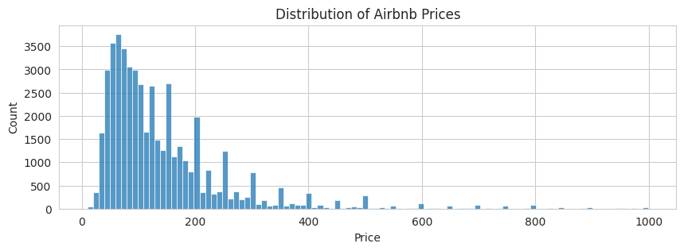

```python
plt.figure(figsize=(10,3))
sns.histplot(df['price'], bins=100)

plt.title('Distribution of Airbnb Prices')
plt.xlabel('Price')
plt.ylabel('Count')

plt.show()
```

### Observation

- Most listings are concentrated in lower price ranges.
- A few expensive listings create a right-skewed distribution.

## 6. Price by Neighborhood

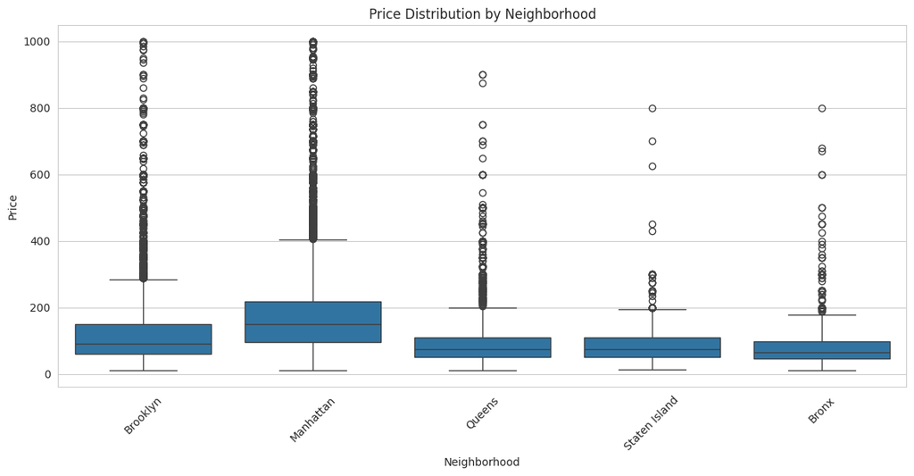

```python
plt.figure(figsize=(14,6))

sns.boxplot(
    x='neighbourhood_group',
    y='price',
    data=df
)

plt.xticks(rotation=45)

plt.title('Price Distribution by Neighborhood')
plt.xlabel('Neighborhood')
plt.ylabel('Price')

plt.show()
```

### Observation

- Some neighborhoods have significantly higher median prices.
- Several outliers are visible in expensive areas.

## 7. Room Type Analysis

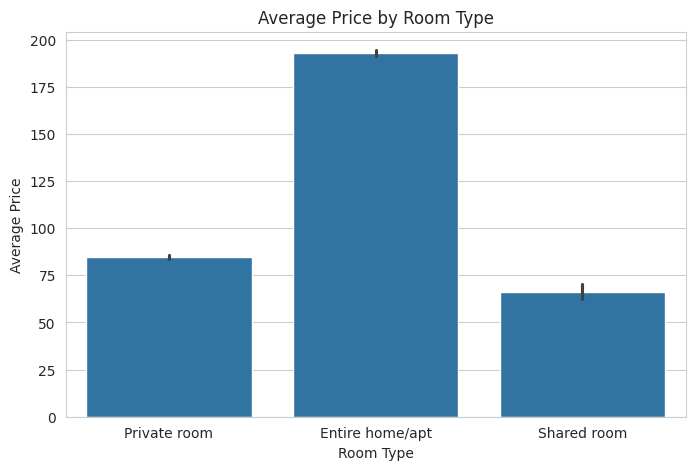

```python
plt.figure(figsize=(8,5))

sns.barplot(
    x='room_type',
    y='price',
    data=df
)

plt.title('Average Price by Room Type')
plt.xlabel('Room Type')
plt.ylabel('Average Price')

plt.show()
```

### Observation

- Entire homes/apartments are generally more expensive.
- Shared rooms are the cheapest option.

## 8. Seasonal Trends

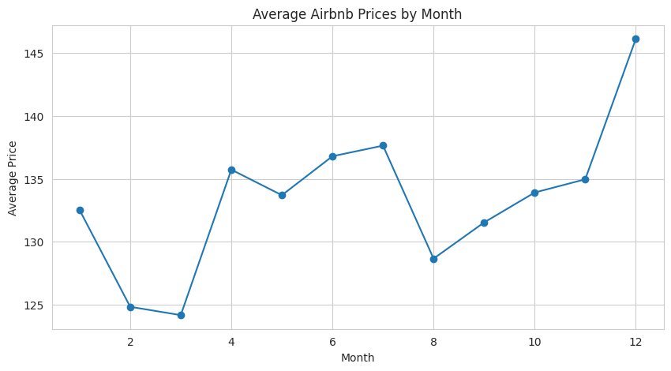

```python
monthly_prices = df.groupby('month')['price'].mean()

plt.figure(figsize=(10,5))

monthly_prices.plot(marker='o')

plt.title('Average Airbnb Prices by Month')
plt.xlabel('Month')
plt.ylabel('Average Price')

plt.show()
```

### Observation

- Prices fluctuate across different months.
- Peak tourist seasons may show higher average prices.

## 9. Reviews vs Price

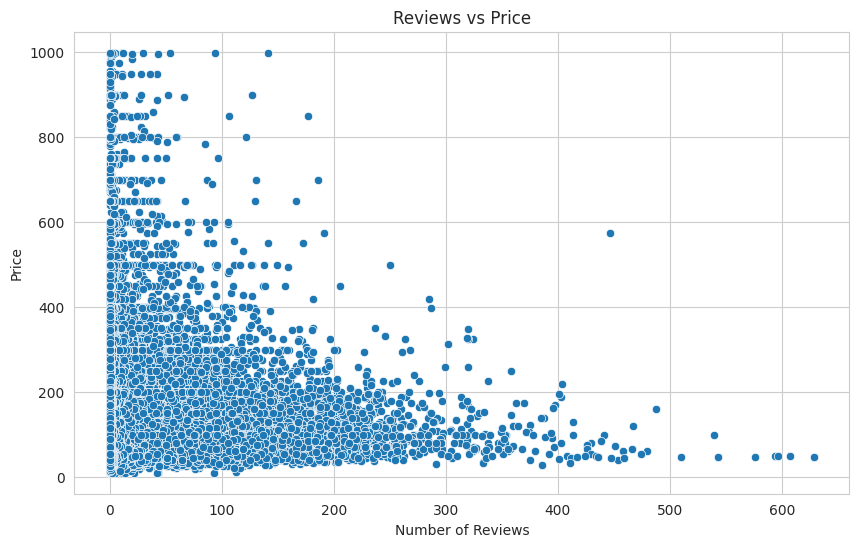

```python
plt.figure(figsize=(10,6))

sns.scatterplot(
    x='number_of_reviews',
    y='price',
    data=df
)

plt.title('Reviews vs Price')
plt.xlabel('Number of Reviews')
plt.ylabel('Price')

plt.show()
```

### Observation

- Listings with very high prices do not always receive more reviews.
- Most reviewed listings fall within moderate price ranges.

## 10. Availability Analysis

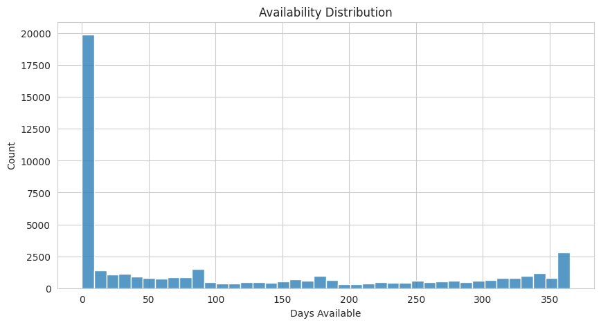

```python
plt.figure(figsize=(10,5))

sns.histplot(df['availability_365'], bins=40)

plt.title('Availability Distribution')
plt.xlabel('Days Available')
plt.ylabel('Count')

plt.show()
```

### Observation

- Many listings are available for only part of the year.
- Some properties remain available almost year-round.

## 11. Correlation Heatmap

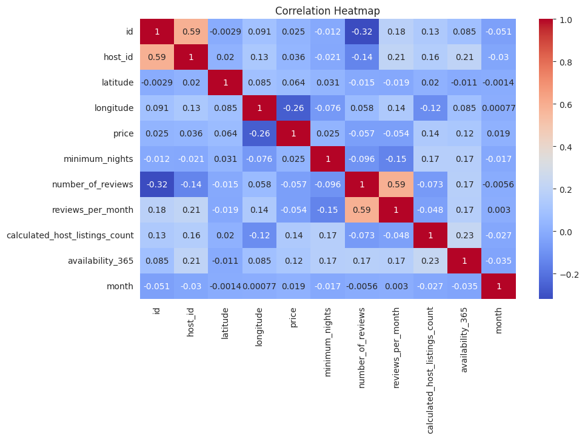

```python
plt.figure(figsize=(10,6))

numeric_df = df.select_dtypes(include=np.number)

sns.heatmap(
    numeric_df.corr(),
    annot=True,
    cmap='coolwarm'
)

plt.title('Correlation Heatmap')

plt.show()
```

## 12. Key Findings

- Airbnb prices vary significantly across neighborhoods.
- Entire homes have the highest average prices.
- The dataset contains several pricing outliers.
- Seasonal patterns may affect listing prices.
- Reviews alone do not strongly determine pricing.

## Conclusion

This exploratory analysis provided insights into Airbnb pricing behavior, room types, neighborhood trends, and seasonal variation. These findings help prepare the dataset for anomaly detection and machine learning modeling.

Preh and Ali used an autoencoder for anomaly detection.

# Section 4 – Self-Supervised Model: Anomaly Detection with an Autoencoder

**Author:** Preh Muneer Abbasi  
**Dataset:** airbnb_cleaned.csv (output from Section 2 – Preprocessing)

## What is an Autoencoder?

An **autoencoder** is a type of neural network that learns to *compress* data and then *reconstruct* it.

```
Input → [Encoder] → Compressed Representation → [Decoder] → Reconstructed Output
```

- We train it **only on normal listings** (removing obvious outliers first).
- After training, the model "knows" what a typical Airbnb listing looks like.
- When we feed it an **anomalous listing** (e.g. suspiciously high price), it cannot reconstruct it well → the **reconstruction error is high**.
- Listings with a high reconstruction error = **anomalies**.

This is called **self-supervised** because we never manually label what is normal or anomalous — the model figures it out by itself.

## Step 0 – Install & Import Libraries

```python
import numpy as np
import pandas as pd
import matplotlib.pyplot as plt
import seaborn as sns

from sklearn.preprocessing import MinMaxScaler
from sklearn.model_selection import train_test_split

import tensorflow as tf
from tensorflow import keras
from tensorflow.keras import layers

print("TensorFlow version:", tf.__version__)
print("All libraries loaded successfully ✓")
```

```
TensorFlow version: 2.20.0
All libraries loaded successfully ✓
```

## Step 1 – Load the Cleaned Dataset

```python
from google.colab import files
uploaded = files.upload()

#Load the cleaned dataset from Section 2
filename = list(uploaded.keys())[0]
df = pd.read_csv(filename)

print(f"Loaded file: {filename}")
print(f"Dataset shape: {df.shape}")
df.head()
```

```
Saving airbnb_cleaned.csv to airbnb_cleaned (2).csv
Loaded file: airbnb_cleaned (2).csv
Dataset shape: (48572, 18)
```

|  | id | name | host_id | host_name | neighbourhood_group | neighbourhood | latitude | longitude | room_type | price | minimum_nights | number_of_reviews | last_review | reviews_per_month | calculated_host_listings_count | availability_365 | month | season |
| --- | --- | --- | --- | --- | --- | --- | --- | --- | --- | --- | --- | --- | --- | --- | --- | --- | --- | --- |
| 0 | 2539 | Clean & quiet apt home by the park | 2787 | John | Brooklyn | Kensington | 40.64749 | -73.97237 | Private room | 149 | 1 | 9 | 2018-10-19 | 0.21 | 6 | 365 | 10.0 | Autumn |
| 1 | 2595 | Skylit Midtown Castle | 2845 | Jennifer | Manhattan | Midtown | 40.75362 | -73.98377 | Entire home/apt | 225 | 1 | 45 | 2019-05-21 | 0.38 | 2 | 355 | 5.0 | Spring |
| 2 | 3647 | THE VILLAGE OF HARLEM....NEW YORK ! | 4632 | Elisabeth | Manhattan | Harlem | 40.80902 | -73.94190 | Private room | 150 | 3 | 0 | NaN | 0.00 | 1 | 365 | NaN | Autumn |
| 3 | 3831 | Cozy Entire Floor of Brownstone | 4869 | LisaRoxanne | Brooklyn | Clinton Hill | 40.68514 | -73.95976 | Entire home/apt | 89 | 1 | 270 | 2019-07-05 | 4.64 | 1 | 194 | 7.0 | Summer |
| 4 | 5022 | Entire Apt: Spacious Studio/Loft by central park | 7192 | Laura | Manhattan | East Harlem | 40.79851 | -73.94399 | Entire home/apt | 80 | 10 | 9 | 2018-11-19 | 0.10 | 1 | 0 | 11.0 | Autumn |

## Step 2 – Select Features for the Autoencoder

We choose **numeric pricing-related features** only. The model will learn the normal patterns across these columns and flag listings that don't fit.

```python
FEATURES = [
    'price',
    'minimum_nights',
    'number_of_reviews',
    'reviews_per_month',
    'calculated_host_listings_count',
    'availability_365'
]

data = df[FEATURES].copy()
data = data.dropna()

print(f"Rows after dropping NaN: {len(data)}")
data.describe()
```

```
Rows after dropping NaN: 48572
```

|  | price | minimum_nights | number_of_reviews | reviews_per_month | calculated_host_listings_count | availability_365 |
| --- | --- | --- | --- | --- | --- | --- |
| count | 48572.000000 | 48572.000000 | 48572.000000 | 48572.000000 | 48572.000000 | 48572.000000 |
| mean | 140.269826 | 6.784176 | 23.378016 | 1.095586 | 7.170345 | 112.314440 |
| std | 112.904535 | 16.129464 | 44.656757 | 1.600025 | 33.050706 | 131.352383 |
| min | 10.000000 | 1.000000 | 0.000000 | 0.000000 | 1.000000 | 0.000000 |
| 25% | 69.000000 | 1.000000 | 1.000000 | 0.040000 | 1.000000 | 0.000000 |
| 50% | 105.000000 | 3.000000 | 5.000000 | 0.380000 | 1.000000 | 44.000000 |
| 75% | 175.000000 | 5.000000 | 24.000000 | 1.600000 | 2.000000 | 225.000000 |
| max | 999.000000 | 365.000000 | 629.000000 | 58.500000 | 327.000000 | 365.000000 |

The model was trained on numerical pricing, availability, and review-related features. Location and room type columns were retained in the final output to support interpretation of the detected anomalies.

## Step 3 – Prepare Training Data (Normal Listings Only)

We train the autoencoder **only on "normal" listings** so it learns what typical looks like.  
We define normal as: price between £10–£500 and minimum_nights ≤ 90.

```python
#Filter to normal listings for training
normal_mask = (
    (data['price'] >= 10) & (data['price'] <= 500) &
    (data['minimum_nights'] <= 90)
)

data_normal = data[normal_mask]
print(f"Normal listings used for training: {len(data_normal)} / {len(data)}")
print(f"Potential anomalies (excluded from training): {len(data) - len(data_normal)}")
```

```
Normal listings used for training: 47656 / 48572
Potential anomalies (excluded from training): 916
```

To train the autoencoder on mostly normal examples, obvious extreme cases were excluded from the training subset. Listings with prices between 10 and 500 and minimum nights of 90 or fewer were treated as normal training examples. This allowed the model to learn the structure of typical listings before being applied to the full cleaned dataset.

```python
#Scale all values to the range [0, 1]
#Neural networks work best when all features are on the same scale.

scaler = MinMaxScaler()

#Fit the scaler on NORMAL data only, then transform the full dataset
X_train_raw = scaler.fit_transform(data_normal)
X_all_scaled = scaler.transform(data)   #Scale full dataset for later anomaly scoring

# Train / Validation split (80% train, 20% validation)
X_train, X_val = train_test_split(X_train_raw, test_size=0.2, random_state=42)

print(f"Training set shape:   {X_train.shape}")
print(f"Validation set shape: {X_val.shape}")
print(f"Full dataset shape:   {X_all_scaled.shape}")
```

```
Training set shape:   (38124, 6)
Validation set shape: (9532, 6)
Full dataset shape:   (48572, 6)
```

## Step 4 – Build the Autoencoder Model

The architecture:

```
Input (6 features)
    ↓
[Encoder]
  Dense(32, relu)
  Dense(16, relu)
  Dense(8, relu)    ← bottleneck (compressed representation)
[Decoder]
  Dense(16, relu)
  Dense(32, relu)
  Dense(6, sigmoid) ← reconstructed output
```

```python
#Here I am setting random seed for reproducibility ──
tf.random.set_seed(42)
np.random.seed(42)

INPUT_DIM = X_train.shape[1]   #Number of features(6)

#Building the Autoencoder, started from this part
def build_autoencoder(input_dim):
    inputs = keras.Input(shape=(input_dim,), name='input')

    #Encoder
    x = layers.Dense(32, activation='relu', name='encoder_1')(inputs)
    x = layers.Dense(16, activation='relu', name='encoder_2')(x)
    encoded = layers.Dense(8,  activation='relu', name='bottleneck')(x)

    #Decoder
    x = layers.Dense(16, activation='relu', name='decoder_1')(encoded)
    x = layers.Dense(32, activation='relu', name='decoder_2')(x)
    decoded = layers.Dense(input_dim, activation='sigmoid', name='output')(x)

    autoencoder = keras.Model(inputs, decoded, name='autoencoder')
    return autoencoder


autoencoder = build_autoencoder(INPUT_DIM)
autoencoder.compile(
    optimizer='adam',
    loss='mse'           #Mean Squared Error: measures how different input vs output is
)
autoencoder.summary()
```

```
Model: "autoencoder"
```

```
┏━━━━━━━━━━━━━━━━━━━━━━━━━━━━━━━━━┳━━━━━━━━━━━━━━━━━━━━━━━━┳━━━━━━━━━━━━━━━┓
┃ Layer (type)                    ┃ Output Shape           ┃       Param # ┃
┡━━━━━━━━━━━━━━━━━━━━━━━━━━━━━━━━━╇━━━━━━━━━━━━━━━━━━━━━━━━╇━━━━━━━━━━━━━━━┩
│ input (InputLayer)              │ (None, 6)              │             0 │
├─────────────────────────────────┼────────────────────────┼───────────────┤
│ encoder_1 (Dense)               │ (None, 32)             │           224 │
├─────────────────────────────────┼────────────────────────┼───────────────┤
│ encoder_2 (Dense)               │ (None, 16)             │           528 │
├─────────────────────────────────┼────────────────────────┼───────────────┤
│ bottleneck (Dense)              │ (None, 8)              │           136 │
├─────────────────────────────────┼────────────────────────┼───────────────┤
│ decoder_1 (Dense)               │ (None, 16)             │           144 │
├─────────────────────────────────┼────────────────────────┼───────────────┤
│ decoder_2 (Dense)               │ (None, 32)             │           544 │
├─────────────────────────────────┼────────────────────────┼───────────────┤
│ output (Dense)                  │ (None, 6)              │           198 │
└─────────────────────────────────┴────────────────────────┴───────────────┘
```

```
 Total params: 1,774 (6.93 KB)
```

```
 Trainable params: 1,774 (6.93 KB)
```

```
 Non-trainable params: 0 (0.00 B)
```

## Step 5 – Train the Model

```python
#Early stopping: stop training if validation loss stops improving
early_stop = keras.callbacks.EarlyStopping(
    monitor='val_loss',
    patience=5,           #Stop after 5 epochs with no improvement
    restore_best_weights=True
)

history = autoencoder.fit(
    X_train, X_train,         #Input = Target (we want the model to reconstruct itself)
    epochs=50,
    batch_size=256,
    validation_data=(X_val, X_val),
    callbacks=[early_stop],
    verbose=1
)

print("\nTraining complete ✓")
```

```
149/149 ━━━━━━━━━━━━━━━━━━━━ 2s 4ms/step - loss: 0.0908 - val_loss: 0.0231
149/149 ━━━━━━━━━━━━━━━━━━━━ 0s 3ms/step - loss: 0.0131 - val_loss: 0.0101
149/149 ━━━━━━━━━━━━━━━━━━━━ 0s 3ms/step - loss: 0.0068 - val_loss: 0.0048
149/149 ━━━━━━━━━━━━━━━━━━━━ 0s 3ms/step - loss: 0.0041 - val_loss: 0.0036
149/149 ━━━━━━━━━━━━━━━━━━━━ 0s 3ms/step - loss: 0.0033 - val_loss: 0.0030
149/149 ━━━━━━━━━━━━━━━━━━━━ 0s 3ms/step - loss: 0.0025 - val_loss: 0.0022
149/149 ━━━━━━━━━━━━━━━━━━━━ 0s 3ms/step - loss: 0.0020 - val_loss: 0.0019
149/149 ━━━━━━━━━━━━━━━━━━━━ 1s 4ms/step - loss: 0.0018 - val_loss: 0.0017
149/149 ━━━━━━━━━━━━━━━━━━━━ 1s 5ms/step - loss: 0.0016 - val_loss: 0.0016
149/149 ━━━━━━━━━━━━━━━━━━━━ 1s 5ms/step - loss: 0.0016 - val_loss: 0.0015
149/149 ━━━━━━━━━━━━━━━━━━━━ 0s 3ms/step - loss: 0.0015 - val_loss: 0.0015
149/149 ━━━━━━━━━━━━━━━━━━━━ 0s 3ms/step - loss: 0.0015 - val_loss: 0.0014
149/149 ━━━━━━━━━━━━━━━━━━━━ 0s 3ms/step - loss: 0.0015 - val_loss: 0.0014
149/149 ━━━━━━━━━━━━━━━━━━━━ 0s 3ms/step - loss: 0.0014 - val_loss: 0.0014
149/149 ━━━━━━━━━━━━━━━━━━━━ 0s 3ms/step - loss: 0.0014 - val_loss: 0.0014
149/149 ━━━━━━━━━━━━━━━━━━━━ 0s 3ms/step - loss: 0.0014 - val_loss: 0.0014
149/149 ━━━━━━━━━━━━━━━━━━━━ 0s 3ms/step - loss: 0.0014 - val_loss: 0.0013
149/149 ━━━━━━━━━━━━━━━━━━━━ 0s 3ms/step - loss: 0.0014 - val_loss: 0.0013
149/149 ━━━━━━━━━━━━━━━━━━━━ 0s 3ms/step - loss: 0.0014 - val_loss: 0.0013
149/149 ━━━━━━━━━━━━━━━━━━━━ 0s 3ms/step - loss: 0.0014 - val_loss: 0.0013
149/149 ━━━━━━━━━━━━━━━━━━━━ 0s 3ms/step - loss: 0.0014 - val_loss: 0.0013
149/149 ━━━━━━━━━━━━━━━━━━━━ 0s 3ms/step - loss: 0.0014 - val_loss: 0.0013
149/149 ━━━━━━━━━━━━━━━━━━━━ 0s 3ms/step - loss: 0.0014 - val_loss: 0.0013
149/149 ━━━━━━━━━━━━━━━━━━━━ 0s 3ms/step - loss: 0.0014 - val_loss: 0.0013
149/149 ━━━━━━━━━━━━━━━━━━━━ 0s 3ms/step - loss: 0.0014 - val_loss: 0.0013
149/149 ━━━━━━━━━━━━━━━━━━━━ 0s 3ms/step - loss: 0.0014 - val_loss: 0.0013
149/149 ━━━━━━━━━━━━━━━━━━━━ 0s 3ms/step - loss: 0.0014 - val_loss: 0.0013
149/149 ━━━━━━━━━━━━━━━━━━━━ 0s 3ms/step - loss: 0.0014 - val_loss: 0.0013
149/149 ━━━━━━━━━━━━━━━━━━━━ 1s 3ms/step - loss: 0.0013 - val_loss: 0.0013
149/149 ━━━━━━━━━━━━━━━━━━━━ 0s 3ms/step - loss: 0.0013 - val_loss: 0.0013
149/149 ━━━━━━━━━━━━━━━━━━━━ 0s 3ms/step - loss: 0.0013 - val_loss: 0.0013
149/149 ━━━━━━━━━━━━━━━━━━━━ 1s 5ms/step - loss: 0.0013 - val_loss: 0.0013
149/149 ━━━━━━━━━━━━━━━━━━━━ 1s 6ms/step - loss: 0.0013 - val_loss: 0.0013
149/149 ━━━━━━━━━━━━━━━━━━━━ 1s 5ms/step - loss: 0.0013 - val_loss: 0.0013
149/149 ━━━━━━━━━━━━━━━━━━━━ 1s 4ms/step - loss: 0.0013 - val_loss: 0.0013
149/149 ━━━━━━━━━━━━━━━━━━━━ 0s 3ms/step - loss: 0.0013 - val_loss: 0.0013
149/149 ━━━━━━━━━━━━━━━━━━━━ 0s 3ms/step - loss: 0.0013 - val_loss: 0.0013
149/149 ━━━━━━━━━━━━━━━━━━━━ 0s 3ms/step - loss: 0.0013 - val_loss: 0.0013
149/149 ━━━━━━━━━━━━━━━━━━━━ 0s 3ms/step - loss: 0.0013 - val_loss: 0.0013
149/149 ━━━━━━━━━━━━━━━━━━━━ 0s 3ms/step - loss: 0.0013 - val_loss: 0.0013
149/149 ━━━━━━━━━━━━━━━━━━━━ 0s 3ms/step - loss: 0.0013 - val_loss: 0.0013
149/149 ━━━━━━━━━━━━━━━━━━━━ 0s 3ms/step - loss: 0.0013 - val_loss: 0.0013
149/149 ━━━━━━━━━━━━━━━━━━━━ 0s 3ms/step - loss: 0.0013 - val_loss: 0.0013
149/149 ━━━━━━━━━━━━━━━━━━━━ 0s 3ms/step - loss: 0.0013 - val_loss: 0.0013
149/149 ━━━━━━━━━━━━━━━━━━━━ 0s 3ms/step - loss: 0.0013 - val_loss: 0.0013
149/149 ━━━━━━━━━━━━━━━━━━━━ 0s 3ms/step - loss: 0.0013 - val_loss: 0.0013
149/149 ━━━━━━━━━━━━━━━━━━━━ 1s 3ms/step - loss: 0.0013 - val_loss: 0.0013
149/149 ━━━━━━━━━━━━━━━━━━━━ 0s 3ms/step - loss: 0.0013 - val_loss: 0.0013
149/149 ━━━━━━━━━━━━━━━━━━━━ 0s 3ms/step - loss: 0.0013 - val_loss: 0.0010
149/149 ━━━━━━━━━━━━━━━━━━━━ 0s 3ms/step - loss: 8.9533e-04 - val_loss: 4.1670e-04

Training complete ✓
```

## Step 6 – Plot Training & Validation Loss

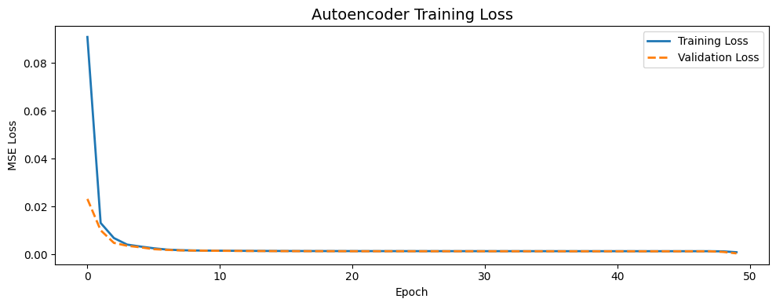

```python
plt.figure(figsize=(10, 4))
plt.plot(history.history['loss'],     label='Training Loss',   linewidth=2)
plt.plot(history.history['val_loss'], label='Validation Loss', linewidth=2, linestyle='--')
plt.title('Autoencoder Training Loss', fontsize=14)
plt.xlabel('Epoch')
plt.ylabel('MSE Loss')
plt.legend()
plt.tight_layout()
plt.savefig('training_loss.png', dpi=150)
plt.show()

# Interpretation
# A good model shows both lines going DOWN and converging.
# If validation loss rises while training loss keeps falling = overfitting.
```

## Step 7 – Calculate Reconstruction Error (Anomaly Score)

For every listing in the **full dataset**, we:

1. Pass it through the trained autoencoder.
2. Compare the original values to the reconstructed values.
3. The **Mean Squared Error (MSE)** per listing is the **anomaly score**.

→ High anomaly score = the model couldn't reconstruct this listing well = it's unusual.

```python
# Reconstructed all listings
X_pred = autoencoder.predict(X_all_scaled, verbose=0)

#Reconstruction error per listing (MSE)
reconstruction_errors = np.mean(np.power(X_all_scaled - X_pred, 2), axis=1)

print(f"Reconstruction Error Statistics:")
print(f"  Min:    {reconstruction_errors.min():.6f}")
print(f"  Max:    {reconstruction_errors.max():.6f}")
print(f"  Mean:   {reconstruction_errors.mean():.6f}")
print(f"  Median: {np.median(reconstruction_errors):.6f}")
```

```
Reconstruction Error Statistics:
  Min:    0.000000
  Max:    1.769343
  Mean:   0.002722
  Median: 0.000183
```

## Step 8 – Set Anomaly Threshold and Label Anomalies

We define the threshold as the **95th percentile** of reconstruction errors on the training set.  
Listings with error above this threshold are flagged as anomalies.

```python
# calculate threshold from training data reconstruction errors.
train_preds = autoencoder.predict(X_train, verbose=0)
train_errors = np.mean(np.power(X_train - train_preds, 2), axis=1)

THRESHOLD = np.percentile(train_errors, 95)
print(f"Anomaly Threshold (95th percentile of training errors): {THRESHOLD:.6f}")

#Label anomalies
is_anomaly = reconstruction_errors > THRESHOLD
print(f"\nTotal listings:  {len(is_anomaly)}")
print(f"Anomalies found: {is_anomaly.sum()} ({is_anomaly.mean()*100:.1f}%)")
```

```
Anomaly Threshold (95th percentile of training errors): 0.001538

Total listings:  48572
Anomalies found: 3287 (6.8%)
```

The Threshold was calculated using the 95th percentile of reconstruction errors from the normal training data. When this threshold was applied to the full dataset, 3287 listings were identified as anomalies, representing 6.80% of the analysed lisitings. The percentage is slightly above 5% because the threshold was learned from normal training data and then applied to the wider dataset, which also contained more unusual lisitings.

## Step 9 – Visualise the Reconstruction Error Distribution

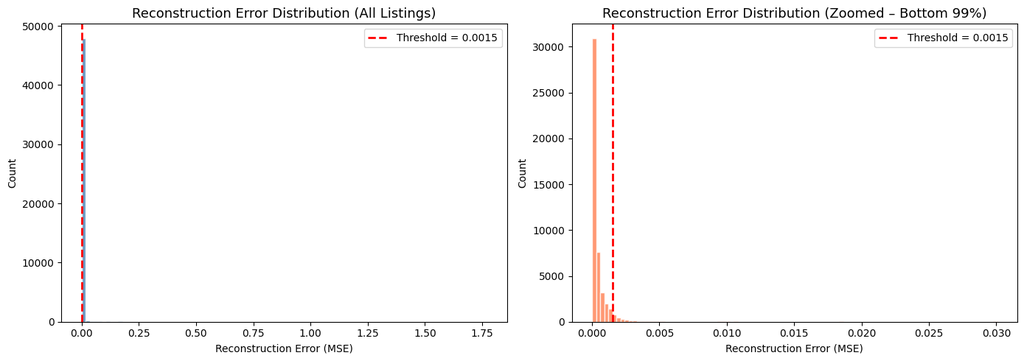

```python
fig, axes = plt.subplots(1, 2, figsize=(14, 5))

#Plot 1: Full distribution
axes[0].hist(reconstruction_errors, bins=100, color='steelblue', edgecolor='white', alpha=0.8)
axes[0].axvline(THRESHOLD, color='red', linestyle='--', linewidth=2, label=f'Threshold = {THRESHOLD:.4f}')
axes[0].set_title('Reconstruction Error Distribution (All Listings)', fontsize=13)
axes[0].set_xlabel('Reconstruction Error (MSE)')
axes[0].set_ylabel('Count')
axes[0].legend()

#Plot 2: Zoom in (exclude top 1% for readability)
clip = np.percentile(reconstruction_errors, 99)
clipped = reconstruction_errors[reconstruction_errors <= clip]
axes[1].hist(clipped, bins=100, color='coral', edgecolor='white', alpha=0.8)
axes[1].axvline(THRESHOLD, color='red', linestyle='--', linewidth=2, label=f'Threshold = {THRESHOLD:.4f}')
axes[1].set_title('Reconstruction Error Distribution (Zoomed – Bottom 99%)', fontsize=13)
axes[1].set_xlabel('Reconstruction Error (MSE)')
axes[1].set_ylabel('Count')
axes[1].legend()

plt.tight_layout()
plt.savefig('reconstruction_error_distribution.png', dpi=150)
plt.show()
```

## Step 10 – Analyse the Anomalies

```python
#Added anomaly results back to the original dataframe
results_df = df.loc[data.index].copy().reset_index(drop=True)
results_df['anomaly_score'] = reconstruction_errors
results_df['is_anomaly'] = is_anomaly

print("Sample of anomalies:")
results_df[results_df['is_anomaly']].sort_values('anomaly_score', ascending=False).head(10)
```

```
Sample of anomalies:
```

|  | id | name | host_id | host_name | neighbourhood_group | neighbourhood | latitude | longitude | room_type | price | minimum_nights | number_of_reviews | last_review | reviews_per_month | calculated_host_listings_count | availability_365 | month | season | anomaly_score | is_anomaly |
| --- | --- | --- | --- | --- | --- | --- | --- | --- | --- | --- | --- | --- | --- | --- | --- | --- | --- | --- | --- | --- |
| 13781 | 10514203 | Giant Landmark Apartment in the Sky | 3710888 | Lisa | Brooklyn | Park Slope | 40.67546 | -73.97528 | Private room | 350 | 365 | 0 | NaN | 0.00 | 1 | 364 | NaN | Autumn | 1.769343 | True |
| 15267 | 12328112 | GREENPOINT OASIS | 1180190 | Justin | Brooklyn | Greenpoint | 40.73100 | -73.95480 | Entire home/apt | 450 | 365 | 17 | 2019-01-03 | 0.50 | 1 | 365 | 1.0 | Winter | 1.765655 | True |
| 2814 | 1586935 | Luxury Gramercy Lg 1Bd w Balcony | 8457613 | Erin | Manhattan | Gramercy | 40.73494 | -73.98751 | Entire home/apt | 250 | 365 | 0 | NaN | 0.00 | 1 | 365 | NaN | Autumn | 1.763984 | True |
| 4738 | 3399909 | Super cute and sunny 2 bedroom | 39304 | Andrea | Brooklyn | Williamsburg | 40.71852 | -73.94165 | Entire home/apt | 240 | 365 | 0 | NaN | 0.00 | 1 | 363 | NaN | Autumn | 1.761836 | True |
| 15859 | 12916189 | Family Friendly BK Townhome With Garden Oasis! | 951917 | Julia And Juan | Brooklyn | Sunset Park | 40.66224 | -73.99805 | Entire home/apt | 196 | 365 | 4 | 2018-05-20 | 0.12 | 1 | 365 | 5.0 | Spring | 1.760066 | True |
| 17212 | 13687060 | Luxury drmn Bldg + Empire State Views & Roof Top! | 21419119 | Sebastien | Manhattan | Kips Bay | 40.74033 | -73.98268 | Entire home/apt | 189 | 365 | 7 | 2018-03-11 | 0.19 | 1 | 362 | 3.0 | Spring | 1.757191 | True |
| 1443 | 649561 | Manhattan Sky Crib (1 year sublet) | 3260084 | David | Manhattan | Chelsea | 40.75164 | -73.99425 | Entire home/apt | 135 | 365 | 0 | NaN | 0.00 | 1 | 365 | NaN | Autumn | 1.756533 | True |
| 5329 | 3891031 | LAST DAY TO BOOK Bedroom on Wall St | 20133610 | Shi Qing | Manhattan | Financial District | 40.70940 | -74.00278 | Private room | 139 | 365 | 13 | 2015-07-15 | 0.23 | 1 | 365 | 7.0 | Summer | 1.756406 | True |
| 753 | 271694 | Easy, comfortable studio in Midtown | 1387370 | James | Manhattan | Midtown | 40.75282 | -73.97315 | Entire home/apt | 125 | 365 | 19 | 2015-09-08 | 0.21 | 1 | 365 | 9.0 | Autumn | 1.755576 | True |
| 2141 | 992977 | Park Slope Pre-War Apartment | 4000059 | Shahdiya | Brooklyn | Park Slope | 40.67359 | -73.97434 | Entire home/apt | 100 | 365 | 1 | 2013-08-01 | 0.01 | 1 | 365 | 8.0 | Summer | 1.755009 | True |

```python
#Top Overpriced Listings (high price anomaly lisitings)
overpriced = results_df[
    results_df['is_anomaly'] & (results_df['price'] > results_df['price'].median())
].sort_values('price', ascending=False)

print("Top 10 High-price Anomaly Listings:")
print(overpriced[['price', 'neighbourhood_group', 'room_type', 'minimum_nights', 'anomaly_score']].head(10).to_string())
```

```
Top 10 High-price Anomaly Listings:
       price neighbourhood_group        room_type  minimum_nights  anomaly_score
46290    999           Manhattan     Private room               1       0.173788
36475    999           Manhattan     Private room               1       0.175465
18387    999           Manhattan  Entire home/apt               2       0.174193
20676    999           Manhattan     Private room               3       0.173976
41123    999           Manhattan     Private room               1       0.173694
10431    999            Brooklyn  Entire home/apt               2       0.182971
9009     999           Manhattan  Entire home/apt               7       0.174468
1891     999           Manhattan     Private room              10       0.175602
14978    999           Manhattan  Entire home/apt               3       0.175460
15040    999           Manhattan  Entire home/apt               2       0.177971
```

```python
#Top Underpriced Listings (low price anomaly lisiting)
underpriced = results_df[
    results_df['is_anomaly'] & (results_df['price'] < results_df['price'].median())
].sort_values('price', ascending=True)

print("Top 10 Low-price Anomaly Listings:")
print(underpriced[['price', 'neighbourhood_group', 'room_type', 'minimum_nights', 'anomaly_score']].head(10).to_string())
```

```
Top 10 Low-price Anomaly Listings:
       price neighbourhood_group        room_type  minimum_nights  anomaly_score
27782     10            Brooklyn  Entire home/apt               1       0.001831
20849     11            Brooklyn  Entire home/apt               2       0.002386
21137     12           Manhattan  Entire home/apt             300       0.928231
45347     13       Staten Island      Shared room               1       0.001975
21589     20               Bronx      Shared room               1       0.001906
36855     20              Queens  Entire home/apt               1       0.008787
28532     25              Queens     Private room               1       0.002432
13978     25            Brooklyn      Shared room               3       0.002803
40909     25              Queens     Private room               1       0.004399
29297     25              Queens     Private room               1       0.002127
```

[figure not shown]

```python
# Price distribution: Normal vs Anomaly
plt.figure(figsize=(12, 5))

plt.subplot(1, 2, 1)
sns.histplot(
    data=results_df[results_df['price'] <= 600],
    x='price', hue='is_anomaly',
    bins=60, palette={True: 'red', False: 'steelblue'}, alpha=0.7
)
plt.title('Price Distribution: Normal vs Anomaly')
plt.xlabel('Price ($)')
plt.legend(title='Is Anomaly', labels=['Normal', 'Anomaly'])

plt.subplot(1, 2, 2)
if 'neighbourhood_group' in results_df.columns:
    anomaly_by_area = results_df.groupby('neighbourhood_group')['is_anomaly'].mean().sort_values(ascending=False)
    anomaly_by_area.plot(kind='bar', color='coral', edgecolor='black')
    plt.title('Anomaly Rate by Neighbourhood Group')
    plt.xlabel('Neighbourhood Group')
    plt.ylabel('Anomaly Rate')
    plt.xticks(rotation=30, ha='right')

plt.tight_layout()
plt.savefig('anomaly_analysis.png', dpi=150)
plt.show()
```

## Step 11 – Save the Output Dataset

```python
#Saved the output CSV with anomaly labels
output_path = 'airbnb_with_anomaly_scores.csv'
results_df.to_csv(output_path, index=False)
print(f"Saved: {output_path}")

#Summary Statistics
print("\n" + "="*40)
print("        SECTION 4 SUMMARY")
print("="*40)
print(f"Total listings analysed : {len(results_df)}")
print(f"Anomalies detected      : {results_df['is_anomaly'].sum()}")
print(f"Anomaly rate            : {results_df['is_anomaly'].mean()*100:.2f}%")
print(f"Anomaly threshold (MSE) : {THRESHOLD:.6f}")
print(f"Mean anomaly score      : {results_df[results_df['is_anomaly']]['anomaly_score'].mean():.6f}")
print(f"\nOutput columns in CSV:")
print(f"  anomaly_score  → reconstruction error per listing (float)")
print(f"  is_anomaly     → True if listing is anomalous, False if normal (bool)")
print("="*40)
```

```
Saved: airbnb_with_anomaly_scores.csv

========================================
        SECTION 4 SUMMARY
========================================
Total listings analysed : 48572
Anomalies detected      : 3287
Anomaly rate            : 6.77%
Anomaly threshold (MSE) : 0.001538
Mean anomaly score      : 0.036315

Output columns in CSV:
  anomaly_score  → reconstruction error per listing (float)
  is_anomaly     → True if listing is anomalous, False if normal (bool)
========================================
```

## Step 12 – Save the Trained Model

```python
#Saved the model for use in Section 5 (NAS Optimisation)
autoencoder.save('autoencoder_base_model.keras')
print("Base model saved as: autoencoder_base_model.keras")
print("This model will be used as the baseline in Section 5 (NAS Optimisation).")
```

```
Base model saved as: autoencoder_base_model.keras
This model will be used as the baseline in Section 5 (NAS Optimisation).
```

## Summary

| Item | Value |
| --- | --- |
| Model type | Autoencoder (Self-Supervised) |
| Framework | TensorFlow / Keras |
| Features used | price, minimum_nights, number_of_reviews, reviews_per_month, calculated_host_listings_count, availability_365 |
| Training data | Normal listings only (price £10–500, min_nights ≤ 90) |
| Anomaly threshold | 95th percentile of training reconstruction errors |
| Output file | `airbnb_with_anomaly_scores.csv` |
| Saved model | `autoencoder_base_model.keras` |

### Key Findings

- The autoencoder successfully learns the distribution of normal Airbnb listings.
- Listings with unusually high prices, extreme minimum night requirements, or atypical review patterns receive high reconstruction errors and are flagged as anomalies.
- The anomaly labels and scores have been exported for use in Section 6 (Evaluation & Final Output Integration).

### References

- Chollet, F. (2021) *Deep Learning with Python*, 2nd edn. Manning Publications.
- TensorFlow/Keras Documentation: https://www.tensorflow.org/api_docs/python/tf/keras
- Bank, D., Koenigstein, N. and Giryes, R. (2023) 'Autoencoders', in *Machine Learning for Data Science Handbook*. Springer. Available at: https://doi.org/10.1007/978-3-031-24628-9_16

My part of the project was to use Neural Architecture Search techniques to choose a machine learning model to answer our business question.

# Airbnb Dataset NAS (Model Optimisation)

## Objective

This notebook starts with a business question, chooses machine learning models to answer the question, prepares the cleaned dataset for those machine learning models, then compares their effectiveness.

## Business Question

*Is a proposed price for a given room type in a given neighbourhood underpriced, in price range, or overpriced?*

## Machine Learning Models

We are working with labeled data and a predefined output (from our business question), so we will use supervised learning. Our output is a classification ("underpriced", "in price range", "overpriced") so we'll use a classification model.

We checked the use cases of many kinds of classification models and chose *not* to use these models.

- Naive Bayes (best for text)
- Logistic Regression (best for binary)
- Support Vector Machines (best for more complex data)
- Random Forests (best for large datasets with complex patterns)
- Linear/Quadratic Discriminant Analysis (requires well-separated classes)
- Gradient Boosting (best for very complex data)

We chose these two models to answer our business question.

- K-Nearest Neighbors
- Decision Tree

## 1. Import Libraries and Data

```python
import pandas as pd
from sklearn.model_selection import train_test_split
from sklearn.neighbors import KNeighborsClassifier
from sklearn import tree
```

```python
df_import = pd.read_csv("airbnb_cleaned.csv")
```

## 2. Select Columns for Models

```python
df = df_import[["neighbourhood_group", "room_type", "number_of_reviews", "availability_365", "price"]]
```

```python
df.head()
```

|  | neighbourhood_group | room_type | number_of_reviews | availability_365 | price |
| --- | --- | --- | --- | --- | --- |
| 0 | Brooklyn | Private room | 9 | 365 | 149 |
| 1 | Manhattan | Entire home/apt | 45 | 355 | 225 |
| 2 | Manhattan | Private room | 0 | 365 | 150 |
| 3 | Brooklyn | Entire home/apt | 270 | 194 | 89 |
| 4 | Manhattan | Entire home/apt | 9 | 0 | 80 |

## 3. Create Price Category Column

```python
df.insert(5, "price_category", pd.NA)
```

```python
df.head()
```

|  | neighbourhood_group | room_type | number_of_reviews | availability_365 | price | price_category |
| --- | --- | --- | --- | --- | --- | --- |
| 0 | Brooklyn | Private room | 9 | 365 | 149 | <NA> |
| 1 | Manhattan | Entire home/apt | 45 | 355 | 225 | <NA> |
| 2 | Manhattan | Private room | 0 | 365 | 150 | <NA> |
| 3 | Brooklyn | Entire home/apt | 270 | 194 | 89 | <NA> |
| 4 | Manhattan | Entire home/apt | 9 | 0 | 80 | <NA> |

## 4. Import Quartile Data

```python
quartiles = pd.read_csv("5_quartiles.csv")
```

```python
quartiles
```

|  | neighbourhood_group | room_type | Q1 | Q3 |
| --- | --- | --- | --- | --- |
| 0 | Bronx | Entire home/apt | 80.0 | 140.0 |
| 1 | Bronx | Private room | 40.0 | 70.0 |
| 2 | Bronx | Shared room | 28.0 | 55.5 |
| 3 | Brooklyn | Entire home/apt | 104.0 | 198.2 |
| 4 | Brooklyn | Private room | 50.0 | 80.0 |
| 5 | Brooklyn | Shared room | 30.0 | 50.0 |
| 6 | Manhattan | Entire home/apt | 140.0 | 250.0 |
| 7 | Manhattan | Private room | 67.0 | 120.0 |
| 8 | Manhattan | Shared room | 49.0 | 88.0 |
| 9 | Queens | Entire home/apt | 90.0 | 165.0 |
| 10 | Queens | Private room | 47.0 | 75.0 |
| 11 | Queens | Shared room | 30.0 | 50.5 |
| 12 | Staten Island | Entire home/apt | 75.0 | 150.0 |
| 13 | Staten Island | Private room | 40.0 | 75.0 |
| 14 | Staten Island | Shared room | 29.0 | 75.0 |

## 5. Put Values in Price Category Column

0: underpriced  
1: in price range  
2: overpriced

```python
for index, row in quartiles.iterrows():
    df.loc[(df["neighbourhood_group"] == row["neighbourhood_group"]) & (df["room_type"] == row["room_type"]) & (df["price"] < row["Q1"]), ["price_category"]] = 0
    df.loc[(df["neighbourhood_group"] == row["neighbourhood_group"]) & (df["room_type"] == row["room_type"]) & (df["price"] >= row["Q1"]) & (df["price"] <= row["Q3"]), ["price_category"]] = 1
    df.loc[(df["neighbourhood_group"] == row["neighbourhood_group"]) & (df["room_type"] == row["room_type"]) & (df["price"] > row["Q3"]), ["price_category"]] = 2
```

## 6. Check for NA Values

```python
pd.isna(df["price_category"]).sum()
```

```
np.int64(0)
```

```python
df.head()
```

|  | neighbourhood_group | room_type | number_of_reviews | availability_365 | price | price_category |
| --- | --- | --- | --- | --- | --- | --- |
| 0 | Brooklyn | Private room | 9 | 365 | 149 | 2 |
| 1 | Manhattan | Entire home/apt | 45 | 355 | 225 | 1 |
| 2 | Manhattan | Private room | 0 | 365 | 150 | 2 |
| 3 | Brooklyn | Entire home/apt | 270 | 194 | 89 | 0 |
| 4 | Manhattan | Entire home/apt | 9 | 0 | 80 | 0 |

## 7. Convert Categories to Integers

neighbourhoods  
1: Bronx  
2: Brooklyn  
3: Manhattan  
4: Queens  
5: Staten Island

room types  
0: Entire home/apt  
1: Private room  
2: Shared room

```python
neighbourhoods = ["", "Bronx", "Brooklyn", "Manhattan", "Queens", "Staten Island"]
for index, n in enumerate(neighbourhoods):
    df.loc[df["neighbourhood_group"] == n, ["neighbourhood_group"]] = index
```

```python
room_types = ["Entire home/apt", "Private room", "Shared room"]
for index, r in enumerate(room_types):
    df.loc[df["room_type"] == r, ["room_type"]] = index
```

```python
df
```

|  | neighbourhood_group | room_type | number_of_reviews | availability_365 | price | price_category |
| --- | --- | --- | --- | --- | --- | --- |
| 0 | 2 | 1 | 9 | 365 | 149 | 2 |
| 1 | 3 | 0 | 45 | 355 | 225 | 1 |
| 2 | 3 | 1 | 0 | 365 | 150 | 2 |
| 3 | 2 | 0 | 270 | 194 | 89 | 0 |
| 4 | 3 | 0 | 9 | 0 | 80 | 0 |
| ... | ... | ... | ... | ... | ... | ... |
| 48567 | 2 | 1 | 0 | 9 | 70 | 1 |
| 48568 | 2 | 1 | 0 | 36 | 40 | 0 |
| 48569 | 3 | 0 | 0 | 27 | 115 | 0 |
| 48570 | 3 | 2 | 0 | 2 | 55 | 1 |
| 48571 | 3 | 1 | 0 | 23 | 90 | 1 |

48572 rows × 6 columns

## 8. Change Data Types to Integer

```python
df = df.astype("int64")
```

```python
df.dtypes
```

```
neighbourhood_group    int64
room_type              int64
number_of_reviews      int64
availability_365       int64
price                  int64
price_category         int64
dtype: object
```

## 9. Split Data into Training and Testing

```python
x_train, x_test, y_train, y_test = train_test_split(df[["neighbourhood_group", "room_type", "price"]], df.price_category, train_size = 0.8)
```

## 10. Test K-Nearest Neighbors Models

```python
# K = 3
knn_3 = KNeighborsClassifier(n_neighbors = 3)
knn_3.fit(x_train, y_train)
knn_3.score(x_test, y_test)
```

```
0.9947503860010294
```

```python
# K = 5
knn_5 = KNeighborsClassifier(n_neighbors = 5)
knn_5.fit(x_train, y_train)
knn_5.score(x_test, y_test)
```

```
0.9904271744724653
```

```python
# K = 10
knn_10 = KNeighborsClassifier(n_neighbors = 10)
knn_10.fit(x_train, y_train)
knn_10.score(x_test, y_test)
```

```
0.9834276891405044
```

## 11. Test Decision Tree Model

```python
dtree = tree.DecisionTreeClassifier()
dtree.fit(x_train, y_train)
dtree.score(x_test, y_test)
```

```
1.0
```

## 12. Test Decision Tree Model with More Columns

```python
x_train, x_test, y_train, y_test = train_test_split(df[["neighbourhood_group", "room_type", "number_of_reviews", "availability_365", "price"]], df.price_category, train_size = 0.8)
dtree.fit(x_train, y_train)
dtree.score(x_test, y_test)
```

```
0.9994853319608852
```

# Conclusion

We used several machine learning classification models on our cleaned dataset to answer our business question.  
*Is a proposed price for a given room type in a given neighbourhood underpriced, in price range, or overpriced?*

We tested several K-Nearest Neighbors models with different values for K - the accuracy was very high.

- K = 3 - accuracy 99.5%
- K = 5 - accuracy 99.0%
- K = 10 - accuracy 98.3%

We tested a Decision Tree model - the accuracy was immediately 100%. (A different train/test split might produce an accuracy slightly less than 100%.)  
We tested what would happen if we added seemingly less relevant columns to the model - "number of reviews" and "availability 365" - the accuracy went below 100%.

The Decision Tree model using "neighbourhood group", "room type" and "price" was the most accurate model we found to answer our business question.

I wanted to show the results from the Decision Tree model with an interactive interface, so I made this web app.

You can choose a neighbourhood and a room type, and the app shows a map of the neighbourhood and the expected price range on a graph. You can then choose an example room price to compare with the price range.

Please try out my web app below!

[interactive chart not shown]

Marwa finished by writing a final evaluation.

# Business Question

Is a proposed price for a given room type in a given neighbourhood underpriced, within the expected price range, or overpriced?

## Results

After the data cleaning process was completed, the final dataset contained 48,572 Airbnb listings and 18 variables. From that point onward, analysis shifted toward exploration - patterns examined, outliers flagged - all built on this refined collection.

The average listing price was $140.27, while the median price was $105. As low as $10 appeared in records, contrasted sharply by a peak at $999. The standard deviation was

$112.90, indicating considerable variation in listing prices across the dataset.

The initial analysis showed that both location and room type have a strong influence on listing prices. Manhattan listings stood out by carrying steeper price tags when compared to areas elsewhere across the city. Entire units - be they full homes or flats - tended to cost more, especially next to private rooms or spaces meant for sharing.

A pattern-finding method based on an Autoencoder helped detect property listings priced outside expected ranges. By studying traits tied to individual ads, it flagged those acting unlike typical market examples. The final Autoencoder model identified 3,287 anomalous listings, representing approximately 6.8% of the dataset. Listings exceeding the anomaly threshold were flagged for further investigation and analysed as potential cases of overpricing, underpricing, or unusual market behaviour.

## Key Insights

Patterns emerged during exploration of the Airbnb data. A close look revealed recurring trends worth noting.

One of the most important findings was the impact of neighbourhood location on listing prices. Prices climbed highest in Manhattan when compared across regions, yet stayed furthest down in the Bronx. Though many factors matter, where something is found tilts the scale early.

Figure 1. Price Distribution by Neighbourhood Group

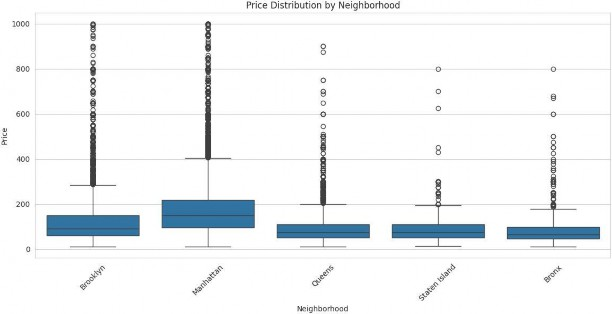

### Figure 1 compares listing prices across neighbourhood groups. Manhattan exhibits the highest median prices and the widest price range, while the Bronx shows the lowest overall pricing levels. Several extreme values are also visible across all neighbourhoods.

Room type was also found to be an important factor affecting listing prices.Entire homes and apartments were generally more expensive than private or shared rooms.

The price distribution was not evenly spread across the dataset. A majority of entries clustered toward cheaper and mid-level costs instead. In contrast, only a few stood far above others in cost. Because of those outliers, the mean shifted upward noticeably. This pattern pulled the shape of the graph to the right slightly.

Figure 2. Distribution of Airbnb Prices

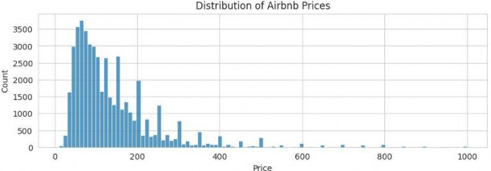

## Patterns Detected

The Autoencoder-based anomaly detection model was trained using key numerical features including price, availability, and review-related variables. Reconstruction error was used as the anomaly score, and listings exceeding the 95th percentile threshold were classified as anomalous.

The model identified 3,287 anomalous listings, representing approximately 6.8% of the analysed Airbnb properties. These listings exhibited characteristics that differed substantially from normal market behaviour and therefore warranted further investigation.

The findings demonstrate that self-supervised learning can effectively identify properties whose characteristics deviate from expected market patterns without requiring

pre-labelled examples of anomalous behaviour. This approach provides a practical method for detecting potentially overpriced, underpriced, or otherwise unusual listings within large accommodation datasets.

## Top Overpriced Listings

Examples of the most notable overpriced listings included:

- Empire City – King Lux King Room (Price: $999)
- Amazing Views 3BR 2BA Bright and Spacious (Price: $999)
- Beautiful 5100 SQ FT Industrial Brooklyn Loft (Price: $999)
- A Suite with Breathtaking Views of NYC! (Price: $999)
- Luxury Full-Floor 2 Bed Loft with Huge Private Roof (Price: $999)

  These listings were primarily located in Manhattan and Brooklyn, where premium accommodation is common. However, the model determined that their overall feature combinations differed significantly from typical listings within the dataset, suggesting that they represent unusually priced properties.

## Top Underpriced Listings

  The model also detected listings that appeared unusually inexpensive when compared with similar properties. Although low prices do not necessarily indicate errors, they may represent promotional pricing, incomplete listing information, data-entry issues, or genuinely undervalued properties.

  Examples of the most notable underpriced listings included:
- Spacious 2-Bedroom Apt in Heart of Greenpoint
- Spacious and Modern 2 Bedroom Apartment
- Studio with Amazing View
- Happy Home 3
- Beautiful Furnished Private Studio with Backyard

  These listings displayed characteristics that differed from the pricing patterns typically observed for comparable properties. Their anomaly scores indicate that they deserve further examination to determine whether the pricing reflects market conditions or unusual listing behaviour.

## Limitations

  One limitation of the current anomaly detection approach is that neighbourhood_group was not included directly as an input feature during Autoencoder training. While this simplified the model and supported the Neural Architecture Search process, it may have reduced the model's ability to identify anomalies relative to local market conditions. Future work could incorporate neighbourhood-specific encoding so that pricing behaviour is evaluated within each geographical area. This may improve the accuracy and interpretability of anomaly detection results.

## Conclusion

  This project analysed Airbnb listings in New York City to better understand pricing patterns and identify unusual market behaviour. After cleaning and exploring the data, clear patterns began to emerge. Location mattered greatly - listings in Manhattan stood out with steeper rates. Entire homes also tended toward higher costs compared to shared or private rooms. Price variation was tied closely not just to area but also to how much space guests could access.

  The findings demonstrate how data analysis and machine learning can be combined to identify meaningful patterns within large datasets. These insights can support better decision-making, improve understanding of market behaviour, and help identify listings that differ from typical pricing trends.

  The anomaly detection model successfully identified listings that deviated from normal market patterns, demonstrating the effectiveness of self-supervised learning for anomaly detection in Airbnb pricing data.

  Furthermore, all project materials, including the source code, notebooks, and implementation files, have been made available through the project GitHub repository to support transparency, reproducibility, and future development:

  https://github.com/Mr-Ratman/ML_team_project

## References

  - Aggarwal, C.C. (2017) Outlier Analysis. 2nd edn. Cham: Springer.
  - Airbnb (2019) New York City Airbnb Open Data. Available at: https://www.kaggle.com/datasets/dgomonov/new-york-city-airbnb-open-data (Accessed: 29 May 2026).
  - Géron, A. (2022) Hands-On Machine Learning with Scikit-Learn, Keras and TensorFlow: Concepts, Tools, and Techniques to Build Intelligent Systems. 3rd edn. Sebastopol, CA: O’Reilly Media.
  - Goodfellow, I., Bengio, Y. and Courville, A. (2016) Deep Learning. Cambridge, MA: MIT Press.
  - Sedgwick, P. (2012) ‘Skewed distributions’, BMJ, 345, p. e7534. Available at: https://doi.org/10.1136/bmj.e7534 (Accessed: 29 May 2026).
  - TensorFlow (2024) Autoencoder Tutorial. Available at: https://www.tensorflow.org/tutorials/generative/autoencoder (Accessed: 29 May 2026).
  - Keras (2024) Keras Documentation. Available at: https://keras.io (Accessed: 29 May 2026).
  - Chalapathy, R. and Chawla, S. (2019) ‘Deep Learning for Anomaly Detection: A Survey’, arXiv preprint arXiv:1901.03407. Available at: https://arxiv.org/abs/1901.03407 (Accessed: 29 May 2026).
  - Elsken, T., Metzen, J.H. and Hutter, F. (2019) ‘Neural Architecture Search: A Survey’, Journal of Machine Learning Research, 20(55), pp. 1–21.

We wrote our final report together.

# ‌Airbnb Dataset Analysis

## ‌Introduction

1. The Airbnb NYC 2019 dataset contains specific information about Airbnb listings in New York City, such as property attributes, host information, geographic location, pricing, availability, and customer review activity. The collection includes thousands of listings from various neighbourhoods and boroughs, providing significant information about the short-term rental industry and client preferences. As digital mediums continue to impact the hospitality sector, data-driven decision-making is becoming increasingly critical for optimizing pricing strategies, analyzing customer behavior, and boosting business results.

   This dataset provides a good basis for studying intelligence for business and predictive analysis in the collaborative economy. Organisations can acquire a better knowledge of economic trends and customer demand by examining the correlations between listing characteristics and pricing behaviour. Furthermore, consumer segmentation can help with specific advertising techniques and budget allocation. According to Mikalef et al. (2019), businesses that effectively use statistical analysis are more inclined to enhance decision-making and achieve higher business performance. As a result, the purpose of this research is to use machine learning techniques to extract useful insights from Airbnb listing information and promote evidence-driven business decisions.

## ‌Business Problem‌

2. One of the most difficult tasks for Airbnb hosts and platform operators is to develop profitable and competitive pricing strategies while also understanding the varied features of clients and listings. Several factors influence the short-term rental market, including neighbourhood location, room type, host activity, availability, and customer feedback.

## ‌Data Preprocessing

3. We began by exploring the initial data, and checking for missing or unexpected values. We were pleased to find the data was already very high quality. There were 48895 records, and the only missing values were 16 "name" values and 21 "host_name" values, which aren't necessary to answer our business question. There were no duplicate records.

   There were some unexpected values.
   - 11 properties had a price of 0.
   - 239 had a price greater than 1000 - the maximum was 10,000.
   - 17,533 properties had an "availability_365" value of 0 - we weren't sure if this meant they were never available or they were fully booked.
   - 197 had a "minimum_nights" value greater than 90 - it seemed unexpected that these could only be booked for longer than 3 months.

     We "cleaned" the dataset with the following steps.
   - We changed the missing "name" and "host_name" values to "Unknown".
   - We removed records with price 0.
   - We removed records with a price of 1000 or more.
   - We removed records with "minimum_nights" of more than 365.

## ‌Exploratory Data Analysis

4. After the dataset had been preprocessed, we could move on to exploratory data analysis. Our goal has been to understand the dataset better using the preprocessed data to explore its structure, pricing, and other characteristics. We decided to use libraries such as Seaborn and Matplotlib, as they provide a great combination of ease of use and the ability to generate visualisations and summaries from complex datasets.

   The analysis focused on identifying trends and creating visualisations based on prices, neighbourhoods, or room types.

   This analysis allowed us to visualise several trends found in the dataset, such as the price distribution, which has proven to be right-skewed (Sedgwick, 2012), with most listings concentrated towards the lower prices, with only a few outliers.

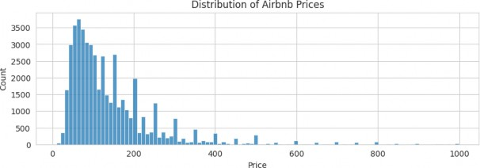

   Another interesting finding has been a correlation between price and neighbourhood, where significant differences have been identified, suggesting that location has a strong influence on the listing price.

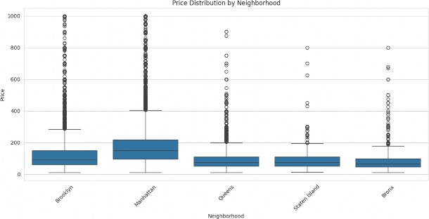

   Furthermore, it has been observed that entire homes and apartments generally tend to have higher prices compared to both private and shared rooms, where the differences fade.

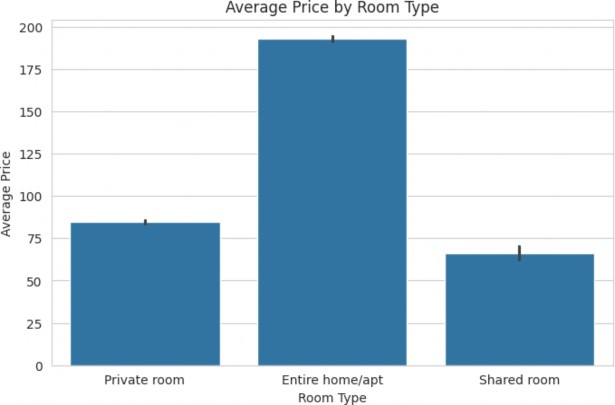

   Overall, the exploratory data analysis provided valuable insights into the dataset, which allowed us to move on to the machine learning analysis.

## ‌Self-Supervised Model (Anomaly Detection)

5. A self-supervised autoencoder (TensorFlow/Keras) was built to detect pricing anomalies without labelled data, by learning normal listing patterns and flagging deviations.

   Six numerical features were selected: price, minimum_nights, number_of_reviews, reviews_per_month, calculated_host_listings_count, and availability_365. The training subset was restricted to listings with prices between £10 and £500 and a minimum stay of 90 nights or fewer, yielding a representative sample of normal behaviour. All features

   were normalised to the range [0, 1] using MinMaxScaler, fitted exclusively on this normal subset to prevent data leakage.

   The autoencoder used a 32 → 16 → 8 encoder and symmetric decoder, trained via Adam/MSE on an 80/20 split with early stopping until loss stabilised.

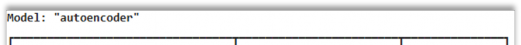

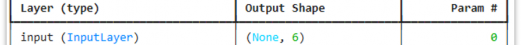

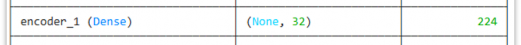

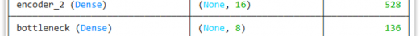

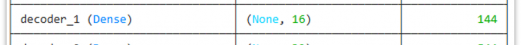

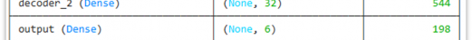

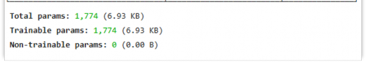

   The trained model scored all 48,572 listings by reconstruction error. Using a 95th percentile threshold, 3,287 anomalies (6.77%) were identified, slightly exceeding 5% as the threshold was derived from normal listings only.

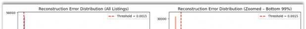

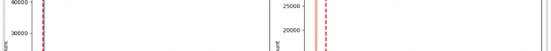

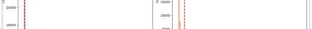

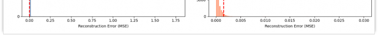

   Anomalies were split into overpriced and underpriced outliers to support pricing decisions. Results were saved with anomaly scores for further use.

[figure not shown]

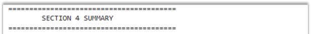

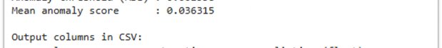

## ‌Neural Architecture Search

6. A Neural Architecture Search tests different statistical models to find the most suitable for a task. We wanted to find the best statistical model to classify prices.

   We know what output we want so we explored supervised rather than unsupervised models.

   We want to classify the data so we explored classification models rather than regression models.

   We considered many kinds of classification models - most are intended for purposes which don’t match our business question, so we tested two in depth - K-Nearest Neighbors and Decision Tree. The Decision Tree model gave the best result - 100% accuracy in our initial test. Here is an interactive demonstration we made to show these results: [price range interface](https://dataandcode.co.uk/price_range_interface.html).

[figure not shown]

[figure not shown]

[figure not shown]

## ‌Evaluation & Final Output Integration

The outputs from each stage of the project were combined to produce a coherent analytical framework for Airbnb listing evaluation. Data preprocessing improved data quality and consistency, exploratory analysis highlighted key pricing patterns, the

self-supervised autoencoder identified anomalous listings, and Neural Architecture Search supported the selection of an appropriate classification approach. Together, these components provided complementary insights that enhanced the interpretation of listing behaviour and demonstrated how machine learning techniques can be integrated to support informed business decisions.

## References

Han, J., Kamber, M. and Pei, J. (2022) Data Mining: Concepts and Techniques. 4th edn. Burlington: Morgan Kaufmann.

Mikalef, P. et al. (2019) ‘Big data analytics and firm performance: Findings from a mixed-method approach’, Journal of Business Research, 98, pp. 261–276.

Sedgwick, P. (2012) 'Skewed distributions', BMJ online, p. 345. Available at: https://doi.org/10.1136/bmj.e7534s

Witten, I.H., Frank, E., Hall, M.A. and Pal, C.J. (2017) Data Mining: Practical Machine Learning Tools and Techniques. 4th edn. Cambridge: Morgan Kaufmann.